# USING OPEN SOURCE DATA TO VISUALIZE BIOLOGICAL, CHEMICAL, AND PHYSICAL OCEANOGRAPHIC PROCESSES

Robert Dellinger

5/5/2022

```r
knitr::opts_chunk$set(warning=FALSE, fig.algin="center", fig.path = '../output/')

devtools::install_github("ropensci/rerddap")
library(oce)
library(ocedata)
library(ncdf4)
library(tidyverse)
library(lubridate)
library(tidync)
library(dplyr)
library(marmap)
library(ggplot2)
library(ggmap)
library(gganimate)
library(stringr)
library(plotly)
library(sf)
library(spData)
library(rerddap)
library(raster)
library(mapdata)
```

# Mapping with the OCE package

# Read in Datasets

The OCE package is a package written by Kelley and Richards (2018) and is focused on oceanographic mapping and plotting that meets publication quality standards. Here, we use the mapPlot() function to create maps using coastline data and visualize oceanographic processes.

# Downloading Data

First we will read in data from the oce package using the data() function

```r
Coastline <- data("coastlineWorld") #coastline data
Coastline_Medium <- data("coastlineWorldMedium") #medium-scale coastline data
Coastline_Fine <- data("coastlineWorldFine") #fine-scale-scale coastline data
Bathymetry <- as.topo(getNOAA.bathy(-180, 0, 0, 90)) #coordinates for bathymetry data from NOAA (Northern Hemisphere)
```

```
## Querying NOAA database ...
```

```
## This may take seconds to minutes, depending on grid size
```

```
## Building bathy matrix ...
```

# Creating a Map

Using the map from the oce package we will create a simple map function that can be rerun

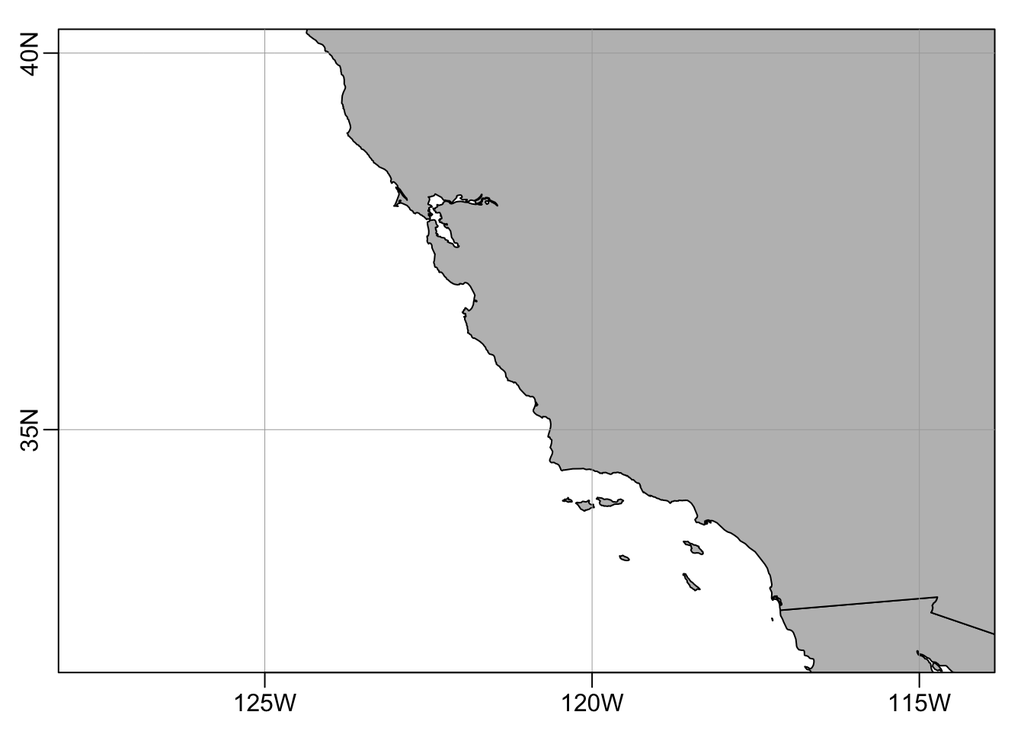

Map of California

```r
# setting the map limits
par(mar=c(2, 2, 1, 1)) # margins
lonlim = c(-126,-116) # longitude
latlim = c(32,40) # latitude

coastline.map <- function() {
  mapPlot(coastlineWorldFine, #using fine-scale data
        projection="+proj=mill", #setting the projection type
        col="grey", #setting colors,
        longitudelim=lonlim,
        latitudelim=latlim,
        lonlabels=TRUE,
        latlabels=TRUE,
        geographical=4,
        clip=TRUE)
}

coastline.map()
```

# Creating a Map with Bathymetry

We will now create a map that mimics the depth of the ocean floor using our previous map function. The provided color palettes in the package can be used to visualize oceanographic phenomena such as bathymetry.

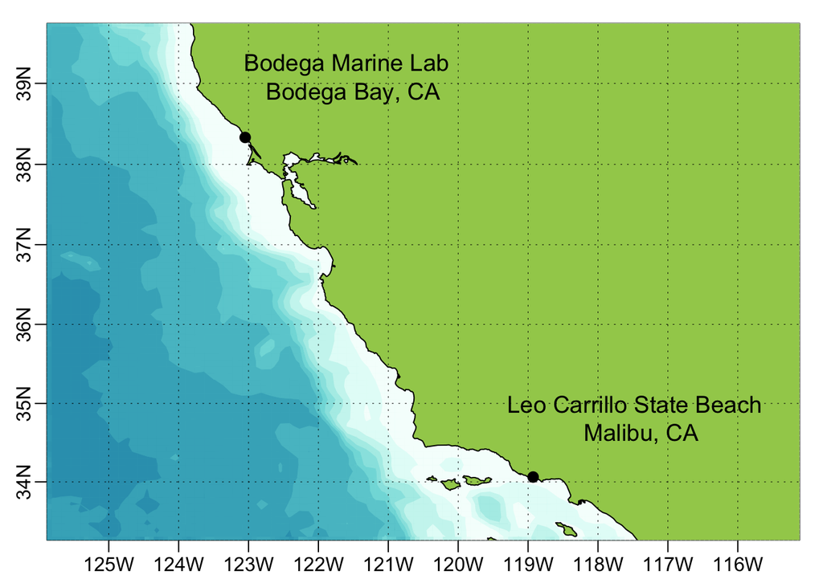

Map of California with Bathymetry

```r
# setting the map limits
par(mar=c(2, 2, 1, 1)) # margins
lonlim = c(-125,-116) # longitude
latlim = c(33.5,39.5) # latitude

#Creating a Map with Bathymetry
#Place Map
coastline.map()
#Overlaying Bathymetry Data
mapImage(Bathymetry, col=oceColorsGebco, breaks=seq(-6000, 0, 100))
mapImage(Bathymetry, col=oceColorsGebco, breaks=seq(-6000, 0, 500), filledContour = TRUE)
#Adding in Coastline
mapPolygon(coastlineWorldFine, col = "darkolivegreen3", border = "black")
#Adding in Grid
mapGrid(dlongitude=1, dlatitude=1, col="black", lty=3)

#Setting points on a map with names and the respective locations
sites = data.frame(name = c("Leo Carrillo State Beach \n Malibu, CA", "Bodega Marine Lab \n Bodega Bay, CA"),
                      lon = c(-118.9279, -123.0481), #locations and their respective longitude and latitudes
                      lat = c(34.0622, 38.3332))
#Placing points on the map
mapPoints(longitude = sites$lon, #placing points on map using longitude
          latitude = sites$lat, #placing points on map using latitude
          pch = 20,
          cex = 1.75)  #point size
#Overlaying text
mapText(longitude = sites$lon+1.5, #map text location long and lat
        latitude = sites$lat+.75,
        labels = sites$name,
        cex = 1.2, #font size
        col="black") # changing font family
```

# Creating a Map with Overlayed SST Data

We will now create a map that mimics that shows us the sea surface temperature of the ocean and use the provided temeprature color palette to visualize differences in ocean temperature. NOAA and NASA provide open source data for marine biology and oceanography data that can be used for creating visuals. For this portion we will use data downloaded from the Group for High Resolution Sea Surface Temperature (GHRSST) which has entire data sets of regional and global data linked here [https://www.ghrsst.org/]. The dataset is provided in a netcdf format so we will have to first read in the data using the nc_open function from the netcdf package (Pierce 2017) prior to graphing.

We will download sea surface temperature (SST) analysis data provided by NOAA which provides a combination of daily satellite and in situ temperature temperature measurements on a global level. We will use data from August 1, 2018, the day of the hottest observed SST by Scripps Institution of Oceanography since the previous record set in 1931.

# Reading in Open Source SST Data from NOAA and NASA

```r
# Opening downloaded data from NOAA
sst.data <- nc_open("/Users/robertdellinger/Documents/Independent_Project_Dellinger/Data/SST_08_01_2018.nc")

# extract the longitude variable
sst.lon = ncvar_get(sst.data, "lon")
# extract the latitude variable
sst.lat = ncvar_get(sst.data, "lat")
# extract sst variable
sst = ncvar_get(sst.data, "analysed_sst")
# extract time

# Kelvin to Degree celsius and calibrate
sst = sst-273.149993896484
```

# Hottest Observed SST for the Southern California Region

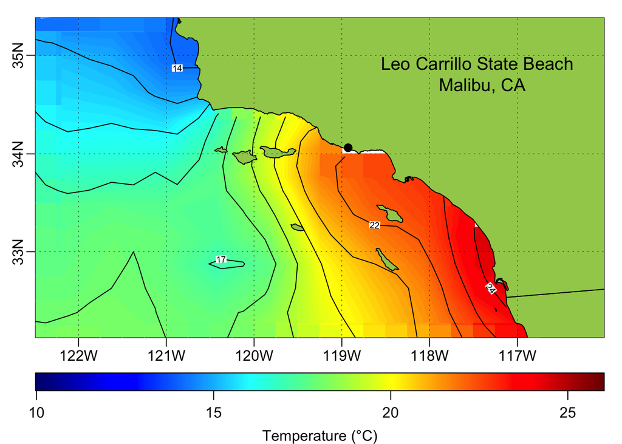

SST Map for Souththern California

```r
# setting the map limits
par(mar=c(2, 2, 1, 1)) # margins
lonlim = c(-122.25,-116.25) # longitude
latlim = c(32.25,35.25) # latitude
templim = c(10,26) #temperature limits in celsisus

# draw palette (must be done before plotting)
drawPalette(zlim = templim,
            zlab = "Temperature (°C)",
            col=oce.colorsJet, #using the oce package temperature colors
            at = seq(10,26,1),
            pos = 1)

#adding in sst to overlay the map function
coastline.map()
mapImage(longitude = sst.lon, latitude = sst.lat, z = sst, zlim = templim, col = oceColorsJet(120))
mapImage(longitude = sst.lon, latitude = sst.lat, z = sst, zlim = templim, col = oceColorsJet(120), filledContour = TRUE)  #overlay sst & contour
mapContour(longitude = sst.lon, latitude = sst.lat, z = sst, levels = seq(10,26,1),
            col = "black", lty = 1, lwd = 1)
mapPolygon(coastlineWorldFine, col="darkolivegreen3") # overlay green topography
mapGrid(dlongitude=1, dlatitude=1, col="black", lty=3) # adding a map grid

#Setting points on a map with names and the respective locations
site = data.frame(name = c("Leo Carrillo State Beach \n Malibu, CA"),
                      lon = -118.9279, #locations and their respective longitude and latitudes
                      lat = 34.0622)
#Placing points on the map
mapPoints(longitude = site$lon, #placing points on map using longitude
          latitude = site$lat, #placing points on map using latitude
          pch = 20,
          cex = 1.75)  #point size
#Overlaying text
mapText(longitude = site$lon+1.5, #map text location long and lat
        latitude = site$lat+.75,
        labels = site$name,
        cex = 1.2, #font size
        col="black") # changing font family
```

# Hottest Observed SST for the Northern California Region

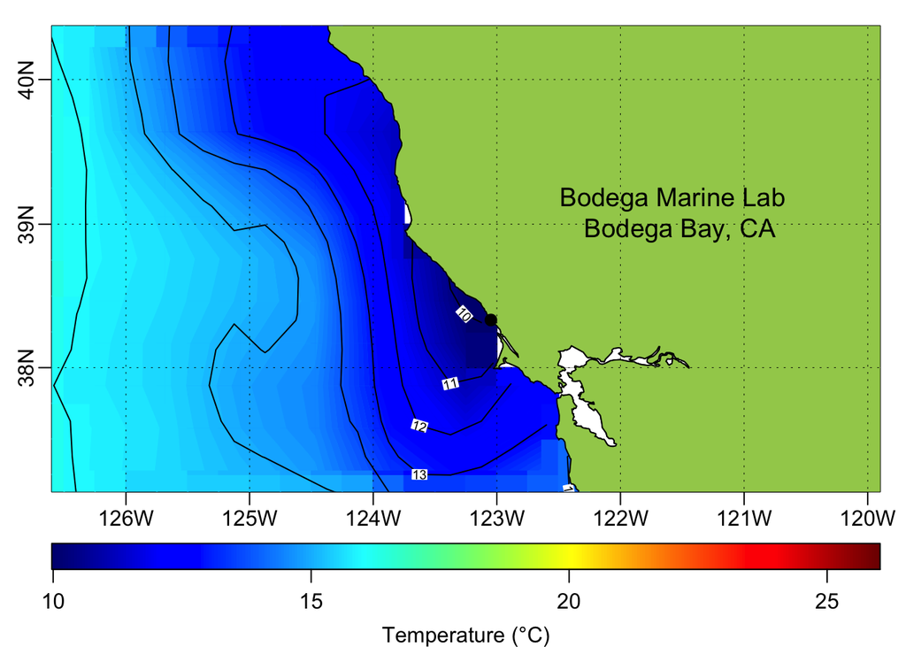

SST Map for Northern California

```r
# setting the map limits
par(mar=c(2, 2, 1, 1)) # margins
lonlim = c(-126.25,-120.25) # longitude
latlim = c(37.25,40.25) # latitude
templim = c(10,26) #temperature limits in celsisus

# draw palette (must be done before plotting)
drawPalette(zlim = templim,
            zlab = "Temperature (°C)",
            col=oce.colorsJet, #using the oce package temperature colors
            at = seq(10,26,1),
            pos = 1)

#adding in sst to overlay the map function
coastline.map()
mapImage(longitude = sst.lon, latitude = sst.lat, z = sst, zlim = templim, col = oceColorsJet(120))
mapImage(longitude = sst.lon, latitude = sst.lat, z = sst, zlim = templim, col = oceColorsJet(120), filledContour = TRUE)  #overlay sst & contour
mapContour(longitude = sst.lon, latitude = sst.lat, z = sst, levels = seq(10,26,1),
            col = "black", lty = 1, lwd = 1)
mapPolygon(coastlineWorldFine, col="darkolivegreen3") # overlay green topography
mapGrid(dlongitude=1, dlatitude=1, col="black", lty=3) # adding a map grid


#Setting points on a map with names and the respective locations
site = data.frame(name = c("Bodega Marine Lab \n Bodega Bay, CA"),
                      lon = -123.0481, #locations and their respective longitude and latitudes
                      lat = 38.3332)
#Placing points on the map
mapPoints(longitude = site$lon, #placing points on map using longitude
          latitude = site$lat, #placing points on map using latitude
          pch = 20,
          cex = 1.75)  #point size
#Overlaying text
mapText(longitude = site$lon+1.5, #map text location long and lat
        latitude = site$lat+.75,
        labels = site$name,
        cex = 1.2, #font size
        col="black") # changing font family
```

# Visualizing Time Series Data

Data was downloaded from NOAA Environmental Research Division Data Access Program (EDRAPP) at a Southern California Coastal Ocean Observation Station (SCCOOS) linked here [https://sccoos.org/]. Data was downloaded from the station at the Santa Monica Pier. This data provides us with the SST measurements taken at frequent intervals for the nearshore coastal ocean of the Los Angeles region.

# Load in Data

```r
sccoss.data <- read_csv("/Users/robertdellinger/Documents/Independent_Project_Dellinger/Data/SCCOSS_SST_LA_01012012_01012022.csv")
names(sccoss.data) <- c("datetime","SST")
```

# Data Wrangling

```r
#clean the data
sccoss.data.clean  <- sccoss.data[-1,] %>% #remove first column
  mutate(datetime = str_remove(datetime, "Z"), #remove z from string
         date = as.Date(ymd(str_split_fixed(datetime, "T", n=Inf)[,1])), #split string into date
         time= str_split_fixed(datetime, "T", n=Inf)[,2], #split string into time
         SST = as.numeric(SST)) %>% #change sst to a numeric value
  filter(SST>10,
         SST<30) %>%
  dplyr::select("date", "SST")

sccoss.summary <- sccoss.data.clean %>%
  group_by(date)%>% # group date
  summarise(SST.mean = mean(SST, na.rm=TRUE), #calculate mean
            SST.sd = sd(SST, na.rm=TRUE),
            SST.min = min(SST, na.rm=TRUE),
            SST.max = max(SST, na.rm=TRUE))

sccoss.dataset <- full_join(sccoss.data.clean, sccoss.summary, by="date") #join data sets

sccoss.timeseries <- sccoss.dataset %>%
  filter(date < ymd("2022-01-01"), #filter years
         date > ymd("2019-01-01"))
```

#Plotting Time Series Temperature Data

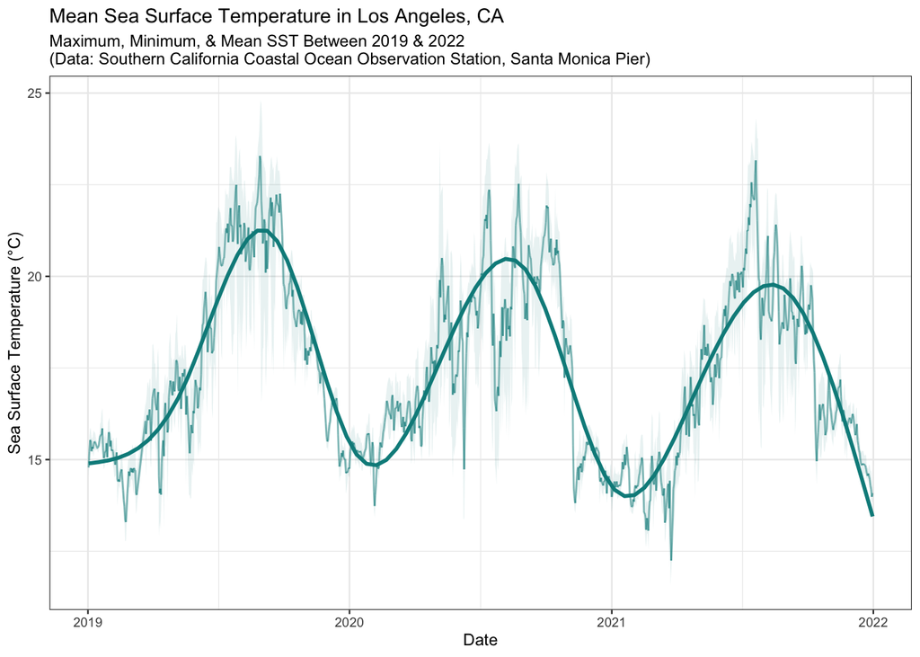

Sea Surface Temperature Time Series for Los Angeles

```r
# make the plot and add labels
sst.plot <- ggplot(sccoss.timeseries, aes(x=date, y=SST.mean)) + #date by mean sst
  geom_line(aes(x=date, y=SST.mean), color="darkcyan", alpha=0.5) +
  geom_smooth(span=0.25, se=FALSE, color="darkcyan") +
  geom_ribbon(aes(ymin=SST.min, ymax=SST.max), fill="darkcyan", alpha=0.1)+
  ylab("Sea Surface Temperature (°C)") +  #add labels
  xlab("Date") +
labs(title = "Mean Sea Surface Temperature in Los Angeles, CA", subtitle = "Maximum, Minimum, & Mean SST Between 2019 & 2022
(Data: Southern California Coastal Ocean Observation Station, Santa Monica Pier)") +
  theme_bw(base_size = 9) #

sst.plot
```